# Correlated Systems of Statistical Equations with Non-Mixture and Mixture Continuous Variables

Allison C Fialkowski

2018-06-21

Systems of statistical equations with correlated variables are common in clinical and genetic studies. These systems may represent repeated measurements or clustered observations. Headrick and Beasley (2004) developed a method for simulating correlated systems of equations containing normal or non-normal continuous variables. The technique allows the user to specify the distributions of the independent variables $X_{(pj)}$, for $p = 1, ..., M$ equations, and stochastic disturbance (error) terms $E$. The user also controls the correlations between: 1) independent variables $X_{(pj)}$ for a given outcome $Y_p$, 2) an outcome $Y_p$ and its $X_{(pj)}$ terms, and 3) stochastic disturbance (error) terms $E$. Their technique calculates the beta (slope) coefficients based on correlations between independent variables $X_{(pj)}$ for a given outcome $Y_p$, the correlations between that outcome $Y_p$ and the $X_{(pj)}$ terms, and the variances. Headrick and Beasley (2004) also derived equations to calculate the expected correlations based on these betas between: 1) $X_{(pj)}$ terms and outcome $Y_q$, 2) outcomes $Y_p$ and $Y_q$, and 3) outcome $Y_p$ and error term $E_q$, for $p$ not equal to $q$. All continuous variables are generated from intermediate random normal variables using Headrick (2002)’s fifth-order power transformation method (PMT). The intermediate correlations required to generate the target correlations after variable transformations are calculated using Headrick (2002)’s equation.

The package **SimRepeat** extends Headrick and Beasley (2004)’s method to include continuous variables (independent variables or error terms) that have mixture distributions. The `nonnormsys` function simulates the system of equations containing correlated continuous normal or non-normal variables with non-mixture or mixture distributions. Mixture distributions are generated using the techniques of Fialkowski (2018). Mixture distributions describe random variables that are drawn from more than one component distribution. Mixture distributions provide a useful way for describing heterogeneity in a population, especially when an outcome is a composite response from multiple sources. For a random variable $Y$ from a finite mixture distribution with $k$ components, the PDF can be described by:
$$h_{Y}(y) = \sum_{i=1}^{k} \pi_{i} f_{Y_{i}}(y),$$
where $\sum_{i=1}^{k} \pi_{i} = 1$. The $\pi_{i}$ are mixing parameters which determine the weight of each component distribution $f_{Y_{i}}(y)$ in the overall probability distribution. The overall distribution $h_{Y}(y)$ has a valid PDF if each component distribution has a valid PDF. The main assumption is statistical independence between the process of randomly selecting the component distribution and the distributions themselves. Assume there is a random selection process that first generates the numbers $1,\ ...,\ k$ with probabilities $\pi_{1},\ ...,\ \pi_{k}$. After selecting number $i$, where $1 \leq i \leq k$, a random variable $y$ is drawn from component distribution $f_{Y_{i}}(y)$ (Davenport, Bezder, and Hathaway 1988; Shork, Allison, and Thiel 1996; Everitt 1996; Pearson 2011).

The package **SimCorrMix** contains vignettes describing mixture variables. Continuous mixture variables are generated componentwise and then transformed to the desired mixture variables using random multinomial variables generated based on mixing probabilities. The correlation matrices are specified in terms of correlations with components of the mixture variables. Headrick and Beasley (2004)’s equations have been adapted in **SimRepeat** to permit mixture variables. These are contained in the functions `calc_betas`, `calc_corr_y`, `calc_corr_ye`, and `calc_corr_yx`.

The package **SimRepeat** also allows the user to specify the correlations between independent variables across outcomes (i.e., $X_{(pj)}$ and $X_{(qj)}$ for $p$ not equal to $q$). This allows imposing a specific correlation structure (i.e., AR(1) or Toeplitz) on time-varying covariates. Independent variables can be designated as the same across outcomes (i.e., to include a stationary covariate as in height). Continuous variables are generated using the techniques of Fialkowski (2017), which permits either Fleishman (1978)’s third-order (`method = "Fleishman"`) or Headrick (2002)’s fifth-order (`method = "Polynomial"`) PMT. When using the fifth-order method, sixth cumulant corrections can be specified in order to obtain random variables with valid probability distribution functions (PDF’s). The error loop from **SimCorrMix** can be used within the `nonnormsys` function to attempt to correct the final correlations among all $X$ terms to be within a user-specified precision value (`epsilon`) of the target correlations.

The following examples demonstrate usage of the `nonnormsys` function. **Example 1** is Headrick and Beasley (2004)’s example from their paper. **Example 2** gives a system with non-mixture and mixture variables. **Example 3** gives a system with missing variables. Details about theory and equations are in the **Theory and Equations for Correlated Systems of Continuous Variables** vignette.

## Example 1: System of three equations for 2 independent variables

In this example taken from Headrick and Beasley (2004):

1. $X_{11}, X_{21}, X_{31}$ each have Exponential(2) distribution
2. $X_{12}, X_{22}, X_{32}$ each have Laplace(0, 1) distribution
3. $E_1, E_2, E_3$ each have Cauchy(0, 1) distribution (the standardized cumulants were taken from the paper)

$$\begin{equation}
\begin{split}
Y_1 &= \beta_{10} + \beta_{11} * X_{11} + \beta_{12} * X_{12} + E_1 \\
Y_2 &= \beta_{20} + \beta_{21} * X_{21} + \beta_{22} * X_{22} + E_2 \\
Y_3 &= \beta_{30} + \beta_{31} * X_{31} + \beta_{32} * X_{32} + E_3
\end{split}
\tag{1}
\end{equation}$$

Each term was generated with zero mean and unit variance. All intercepts were set at $0$. The correlations were given as:

1. $\rho_{X_{11}, X_{12}} = 0.10$, $\rho_{X_{21}, X_{22}} = 0.35$, $\rho_{X_{31}, X_{32}} = 0.70$
2. $\rho_{Y_1, X_{11}} = \rho_{Y_1, X_{12}} = 0.40$, $\rho_{Y_2, X_{21}} = \rho_{Y_2, X_{22}} = 0.50$, $\rho_{Y_3, X_{31}} = \rho_{Y_3, X_{32}} = 0.60$
3. $\rho_{E_1, E_2} = \rho_{E_1, E_3} = \rho_{E_2, E_3} = 0.40$

The across outcome correlations between $X$ terms were set as below in order to obtain the same results as in the paper. No sixth cumulant corrections were used, although the Laplace(0, 1) distribution requires a correction of $25.14$ in order to have a valid PDF.

### Step 1: Set up parameter inputs

```r
library("SimRepeat")
library("printr")
options(scipen = 999)
seed <- 111
n <- 10000
M <- 3

method <- "Polynomial"
Stcum1 <- calc_theory("Exponential", 2)
Stcum2 <- calc_theory("Laplace", c(0, 1))
Stcum3 <- c(0, 1, 0, 25, 0, 1500)

means <- lapply(seq_len(M), function(x) rep(0, 3))
vars <- lapply(seq_len(M), function(x) rep(1, 3))

skews <- lapply(seq_len(M), function(x) c(Stcum1[3], Stcum2[3], Stcum3[3]))
skurts <- lapply(seq_len(M), function(x) c(Stcum1[4], Stcum2[4], Stcum3[4]))
fifths <- lapply(seq_len(M), function(x) c(Stcum1[5], Stcum2[5], Stcum3[5]))
sixths <- lapply(seq_len(M), function(x) c(Stcum1[6], Stcum2[6], Stcum3[6]))
Six <- list()

# Note the following would be used to obtain all valid PDF's
# Six <- lapply(seq_len(M), function(x) list(NULL, 25.14, NULL))

betas.0 <- 0
corr.x <- list()
corr.x[[1]] <- corr.x[[2]] <- corr.x[[3]] <- list()
corr.x[[1]][[1]] <- matrix(c(1, 0.1, 0.1, 1), nrow = 2, ncol = 2)
corr.x[[1]][[2]] <- matrix(c(0.1974318, 0.1859656, 0.1879483, 0.1858601),
                           2, 2, byrow = TRUE)
corr.x[[1]][[3]] <- matrix(c(0.2873190, 0.2589830, 0.2682057, 0.2589542),
                           2, 2, byrow = TRUE)
corr.x[[2]][[1]] <- t(corr.x[[1]][[2]])
corr.x[[2]][[2]] <- matrix(c(1, 0.35, 0.35, 1), nrow = 2, ncol = 2)
corr.x[[2]][[3]] <- matrix(c(0.5723303, 0.4883054, 0.5004441, 0.4841808),
                           2, 2, byrow = TRUE)
corr.x[[3]][[1]] <- t(corr.x[[1]][[3]])
corr.x[[3]][[2]] <- t(corr.x[[2]][[3]])
corr.x[[3]][[3]] <- matrix(c(1, 0.7, 0.7, 1), nrow = 2, ncol = 2)

corr.yx <- list(matrix(c(0.4, 0.4), 1), matrix(c(0.5, 0.5), 1),
  matrix(c(0.6, 0.6), 1))
corr.e <- matrix(0.4, nrow = M, ncol = M)
diag(corr.e) <- 1
error_type <- "non_mix"
```

### Step 2: Check parameter inputs

```r
checkpar(M, method, error_type, means, vars, skews, skurts, fifths, sixths,
  Six, betas.0 = betas.0, corr.x = corr.x, corr.yx = corr.yx, corr.e = corr.e,
  quiet = TRUE)
```

```
## [1] TRUE
```

### Step 3: Generate system

```r
Sys1 <- nonnormsys(n, M, method, error_type, means, vars, skews, skurts,
  fifths, sixths, Six, betas.0 = betas.0, corr.x = corr.x, corr.yx = corr.yx,
  corr.e = corr.e, seed = seed, quiet = TRUE)
```

```
## Total Simulation time: 0.049 minutes
```

```r
knitr::kable(Sys1$betas, booktabs = TRUE, caption = "Beta coefficients")
```

Table 1: Beta coefficients

|  | B1 | B2 |
| --- | --- | --- |
| Y1 | 0.4318335 | 0.4318335 |
| Y2 | 0.4667600 | 0.4667598 |
| Y3 | 0.4648507 | 0.4648503 |

```r
knitr::kable(Sys1$constants[[1]], booktabs = TRUE, caption = "PMT constants")
```

Table 2: PMT constants

| c0 | c1 | c2 | c3 | c4 | c5 |
| --- | --- | --- | --- | --- | --- |
| -0.3077396 | 0.8005605 | 0.318764 | 0.0335001 | -0.0036748 | 0.0001587 |
| 0.0000000 | 0.7277089 | 0.000000 | 0.0963035 | 0.0000000 | -0.0022321 |
| 0.0000000 | -0.1596845 | 0.000000 | 0.3550358 | 0.0000000 | -0.0094729 |

```r
Sys1$valid.pdf
```

```
## [[1]]
## [1] "TRUE"  "FALSE" "FALSE"
##
## [[2]]
## [1] "TRUE"  "FALSE" "FALSE"
##
## [[3]]
## [1] "TRUE"  "FALSE" "FALSE"
```

### Step 4: Describe results

```r
Sum1 <- summary_sys(Sys1$Y, Sys1$E, E_mix = NULL, Sys1$X, Sys1$X_all, M,
  method, means, vars, skews, skurts, fifths, sixths, corr.x = corr.x,
  corr.e = corr.e)
```

```r
knitr::kable(Sum1$cont_sum_y, booktabs = TRUE,
  caption = "Simulated Distributions of Outcomes")
```

Table 3: Simulated Distributions of Outcomes

|  | Outcome | N | Mean | SD | Median | Min | Max | Skew | Skurtosis | Fifth | Sixth |
| --- | --- | --- | --- | --- | --- | --- | --- | --- | --- | --- | --- |
| Y1 | 1 | 10000 | 0.0071862 | 1.184474 | -0.0735469 | -12.27685 | 9.139193 | 0.0593231 | 10.859887 | -15.709407 | 344.2901 |
| Y2 | 2 | 10000 | 0.0029877 | 1.253034 | -0.0880282 | -10.82648 | 10.005708 | 0.3167011 | 9.653009 | 4.236132 | 271.6446 |
| Y3 | 3 | 10000 | 0.0100362 | 1.308292 | -0.1012901 | -12.35040 | 14.358996 | 0.4478936 | 10.291990 | 10.681747 | 419.8943 |

```r
knitr::kable(Sum1$target_sum_x, booktabs = TRUE,
  caption = "Target Distributions of Independent Variables")
```

Table 4: Target Distributions of Independent Variables

|  | Outcome | X | Mean | SD | Skew | Skurtosis | Fifth | Sixth |
| --- | --- | --- | --- | --- | --- | --- | --- | --- |
| cont1_1 | 1 | 1 | 0 | 1 | 2 | 6 | 24 | 120 |
| cont1_2 | 1 | 2 | 0 | 1 | 0 | 3 | 0 | 30 |
| cont2_1 | 2 | 1 | 0 | 1 | 2 | 6 | 24 | 120 |
| cont2_2 | 2 | 2 | 0 | 1 | 0 | 3 | 0 | 30 |
| cont3_1 | 3 | 1 | 0 | 1 | 2 | 6 | 24 | 120 |
| cont3_2 | 3 | 2 | 0 | 1 | 0 | 3 | 0 | 30 |

```r
knitr::kable(Sum1$cont_sum_x, booktabs = TRUE,
  caption = "Simulated Distributions of Independent Variables")
```

Table 5: Simulated Distributions of Independent Variables

|  | Outcome | X | N | Mean | SD | Median | Min | Max | Skew | Skurtosis | Fifth | Sixth |
| --- | --- | --- | --- | --- | --- | --- | --- | --- | --- | --- | --- | --- |
| cont1_1 | 1 | 1 | 10000 | -0.0008979 | 0.9972631 | -0.2978603 | -1.328231 | 9.250562 | 2.0468429 | 6.364092 | 25.635123 | 119.57370 |
| cont1_2 | 1 | 2 | 10000 | -0.0011300 | 1.0028701 | 0.0063327 | -7.066301 | 5.654474 | -0.1199282 | 3.037337 | -3.488146 | 27.09002 |
| cont2_1 | 2 | 1 | 10000 | -0.0010172 | 0.9928807 | -0.2910767 | -1.291738 | 8.621562 | 2.0224749 | 6.245030 | 24.969443 | 112.32254 |
| cont2_2 | 2 | 2 | 10000 | -0.0008947 | 1.0008280 | -0.0017667 | -7.616110 | 6.442554 | -0.0951022 | 3.630147 | -4.626091 | 60.43407 |
| cont3_1 | 3 | 1 | 10000 | -0.0002394 | 0.9984306 | -0.3077666 | -1.578368 | 9.545770 | 2.0078250 | 6.085216 | 24.522409 | 120.55127 |
| cont3_2 | 3 | 2 | 10000 | -0.0003199 | 0.9874384 | -0.0012571 | -6.035376 | 5.227375 | -0.0527893 | 2.236968 | -1.027774 | 12.76165 |

```r
knitr::kable(Sum1$target_sum_e, booktabs = TRUE,
  caption = "Target Distributions of Error Terms")
```

Table 6: Target Distributions of Error Terms

|  | Outcome | Mean | SD | Skew | Skurtosis | Fifth | Sixth |
| --- | --- | --- | --- | --- | --- | --- | --- |
| E1 | 1 | 0 | 1 | 0 | 25 | 0 | 1500 |
| E2 | 2 | 0 | 1 | 0 | 25 | 0 | 1500 |
| E3 | 3 | 0 | 1 | 0 | 25 | 0 | 1500 |

```r
knitr::kable(Sum1$cont_sum_e, booktabs = TRUE,
  caption = "Simulated Distributions of Error Terms")
```

Table 7: Simulated Distributions of Error Terms

|  | Outcome | N | Mean | SD | Median | Min | Max | Skew | Skurtosis | Fifth | Sixth |
| --- | --- | --- | --- | --- | --- | --- | --- | --- | --- | --- | --- |
| E1 | 1 | 10000 | 0.0080619 | 0.9935061 | -0.0004688 | -11.77427 | 8.960461 | -0.1369344 | 21.30282 | -35.984933 | 965.4108 |
| E2 | 2 | 10000 | 0.0038802 | 0.9978020 | -0.0012622 | -13.02425 | 10.362046 | 0.1759016 | 24.93013 | 1.313834 | 1463.0695 |
| E3 | 3 | 10000 | 0.0102962 | 0.9951096 | 0.0001988 | -12.04561 | 12.090892 | 0.4188715 | 26.37023 | 26.936516 | 1586.3607 |

Maximum Correlation Errors for X Variables by Outcome:

```r
maxerr <- do.call(rbind, Sum1$maxerr)
rownames(maxerr) <- colnames(maxerr) <- paste("Y", 1:M, sep = "")
knitr::kable(as.data.frame(maxerr), digits = 5, booktabs = TRUE,
  caption = "Maximum Correlation Errors for X Variables")
```

Table 8: Maximum Correlation Errors for X Variables

|  | Y1 | Y2 | Y3 |
| --- | --- | --- | --- |
| Y1 | 0.00413 | 0.00205 | 0.00575 |
| Y2 | 0.00205 | 0.00495 | 0.00541 |
| Y3 | 0.00575 | 0.00541 | 0.00516 |

### Step 5: Compare simulated correlations to theoretical values

```r
knitr::kable(calc_corr_y(Sys1$betas, corr.x, corr.e, vars),
  booktabs = TRUE, caption = "Expected Y Correlations")
```

Table 9: Expected Y Correlations

|  | Y1 | Y2 | Y3 |
| --- | --- | --- | --- |
| Y1 | 1.0000000 | 0.3692526 | 0.3935111 |
| Y2 | 0.3692526 | 1.0000000 | 0.5083399 |
| Y3 | 0.3935111 | 0.5083399 | 1.0000000 |

```r
knitr::kable(Sum1$rho.y, booktabs = TRUE,
  caption = "Simulated Y Correlations")
```

Table 10: Simulated Y Correlations

|  | Y1 | Y2 | Y3 |
| --- | --- | --- | --- |
| Y1 | 1.0000000 | 0.3741871 | 0.4015689 |
| Y2 | 0.3741871 | 1.0000000 | 0.5019800 |
| Y3 | 0.4015689 | 0.5019800 | 1.0000000 |

```r
knitr::kable(calc_corr_ye(Sys1$betas, corr.x, corr.e, vars),
  booktabs = TRUE, caption = "Expected Y, E Correlations")
```

Table 11: Expected Y, E Correlations

|  | E1 | E2 | E3 |
| --- | --- | --- | --- |
| Y1 | 0.8420754 | 0.3368301 | 0.3368301 |
| Y2 | 0.3173969 | 0.7934921 | 0.3173969 |
| Y3 | 0.3037028 | 0.3037028 | 0.7592569 |

```r
knitr::kable(Sum1$rho.ye,
  booktabs = TRUE, caption = "Simulated Y, E Correlations")
```

Table 12: Simulated Y, E Correlations

|  | E1 | E2 | E3 |
| --- | --- | --- | --- |
| Y1 | 0.8405035 | 0.3422090 | 0.3489198 |
| Y2 | 0.3218245 | 0.7931439 | 0.3098100 |
| Y3 | 0.3100882 | 0.2917064 | 0.7603231 |

```r
knitr::kable(calc_corr_yx(Sys1$betas, corr.x, vars),
  booktabs = TRUE, caption = "Expected Y, X Correlations")
```

Table 13: Expected Y, X Correlations

|  | X1_1 | X1_2 |
| --- | --- | --- |
| Y1 | 0.4000000 | 0.4000000 |
| Y2 | 0.1419990 | 0.1384475 |
| Y3 | 0.1928124 | 0.1860563 |

|  | X2_1 | X2_2 |
| --- | --- | --- |
| Y1 | 0.1401382 | 0.1352093 |
| Y2 | 0.5000000 | 0.4999998 |
| Y3 | 0.3743418 | 0.3475145 |

|  | X3_1 | X3_2 |
| --- | --- | --- |
| Y1 | 0.2020090 | 0.1883408 |
| Y2 | 0.3973238 | 0.3601800 |
| Y3 | 0.5999997 | 0.5999996 |

```r
knitr::kable(Sum1$rho.yx,
  booktabs = TRUE, caption = "Simulated Y, X Correlations")
```

Table 14: Simulated Y, X Correlations

|  | X1_1 | X1_2 |
| --- | --- | --- |
| Y1 | 0.4013407 | 0.4077626 |
| Y2 | 0.1413510 | 0.1445654 |
| Y3 | 0.1980463 | 0.1900016 |

|  | X2_1 | X2_2 |
| --- | --- | --- |
| Y1 | 0.1408618 | 0.1330024 |
| Y2 | 0.4987203 | 0.4934377 |
| Y3 | 0.3818031 | 0.3446263 |

|  | X3_1 | X3_2 |
| --- | --- | --- |
| Y1 | 0.1976696 | 0.1882595 |
| Y2 | 0.3899509 | 0.3648209 |
| Y3 | 0.5952966 | 0.5999793 |

## Example 2: System of 3 equations, each with 2 continuous non-mixture covariates and 1 mixture covariate

In this example:

1. $X_{11} = X_{21} = X_{31}$ has a Logistic(0, 1) distribution and is the same variable for each Y (*static* covariate)
2. $X_{12}, X_{22}, X_{32}$ each have a Beta(4, 1.5) distribution
3. $X_{13}, X_{23}, X_{33}$ each have a Normal(-2, 1), Normal(2, 1) mixture distribution
4. $E_1, E_2, E_3$ each have a Logistic(0, 1), Chisq(4), Beta(4, 1.5) mixture distribution

$$\begin{equation}
\begin{split}
Y_1 &= \beta_{10} + \beta_{11} * X_{11} + \beta_{12} * X_{12} + \beta_{13} * X_{13} + E_1 \\
Y_2 &= \beta_{20} + \beta_{21} * X_{11} + \beta_{22} * X_{22} + \beta_{23} * X_{23} + E_2 \\
Y_3 &= \beta_{30} + \beta_{31} * X_{11} + \beta_{32} * X_{32} + \beta_{33} * X_{33} + E_3
\end{split}
\tag{2}
\end{equation}$$

### Step 1: Set up parameter inputs

```r
seed <- 276
n <- 10000
M <- 3

method <- "Polynomial"
L <- calc_theory("Logistic", c(0, 1))
C <- calc_theory("Chisq", 4)
B <- calc_theory("Beta", c(4, 1.5))

skews <- lapply(seq_len(M), function(x) c(L[3], B[3]))
skurts <- lapply(seq_len(M), function(x) c(L[4], B[4]))
fifths <- lapply(seq_len(M), function(x) c(L[5], B[5]))
sixths <- lapply(seq_len(M), function(x) c(L[6], B[6]))
Six <- lapply(seq_len(M), function(x) list(1.75, 0.03))

mix_pis <- lapply(seq_len(M), function(x) list(c(0.4, 0.6), c(0.3, 0.2, 0.5)))
mix_mus <- lapply(seq_len(M), function(x) list(c(-2, 2), c(L[1], C[1], B[1])))
mix_sigmas <- lapply(seq_len(M),
  function(x) list(c(1, 1), c(L[2], C[2], B[2])))
mix_skews <- lapply(seq_len(M),
  function(x) list(c(0, 0), c(L[3], C[3], B[3])))
mix_skurts <- lapply(seq_len(M),
  function(x) list(c(0, 0), c(L[4], C[4], B[4])))
mix_fifths <- lapply(seq_len(M),
  function(x) list(c(0, 0), c(L[5], C[5], B[5])))
mix_sixths <- lapply(seq_len(M),
  function(x) list(c(0, 0), c(L[6], C[6], B[6])))
mix_Six <- lapply(seq_len(M), function(x) list(NULL, NULL, 1.75, NULL, 0.03))
Nstcum <- calc_mixmoments(mix_pis[[1]][[1]], mix_mus[[1]][[1]],
  mix_sigmas[[1]][[1]], mix_skews[[1]][[1]], mix_skurts[[1]][[1]],
  mix_fifths[[1]][[1]], mix_sixths[[1]][[1]])
Mstcum <- calc_mixmoments(mix_pis[[2]][[2]], mix_mus[[2]][[2]],
  mix_sigmas[[2]][[2]], mix_skews[[2]][[2]], mix_skurts[[2]][[2]],
  mix_fifths[[2]][[2]], mix_sixths[[2]][[2]])
means <- lapply(seq_len(M),
  function(x) c(L[1], B[1], Nstcum[1], Mstcum[1]))
vars <- lapply(seq_len(M),
  function(x) c(L[2]^2, B[2]^2, Nstcum[2]^2, Mstcum[2]^2))

same.var <- 1
betas.0 <- 0

corr.x <- list()
corr.x[[1]] <- list(matrix(0.1, 4, 4), matrix(0.2, 4, 4), matrix(0.3, 4, 4))
diag(corr.x[[1]][[1]]) <- 1

# set correlations between components of the same mixture variable to 0
corr.x[[1]][[1]][3:4, 3:4] <- diag(2)

# since X1 is the same across outcomes, set correlation the same
corr.x[[1]][[2]][, same.var] <- corr.x[[1]][[3]][, same.var] <-
  corr.x[[1]][[1]][, same.var]

corr.x[[2]] <- list(t(corr.x[[1]][[2]]), matrix(0.35, 4, 4), matrix(0.4, 4, 4))
diag(corr.x[[2]][[2]]) <- 1

# set correlations between components of the same mixture variable to 0
corr.x[[2]][[2]][3:4, 3:4] <- diag(2)

# since X1 is the same across outcomes, set correlation the same
corr.x[[2]][[2]][, same.var] <- corr.x[[2]][[3]][, same.var] <-
  t(corr.x[[1]][[2]][same.var, ])
corr.x[[2]][[3]][same.var, ] <- corr.x[[1]][[3]][same.var, ]
corr.x[[2]][[2]][same.var, ] <- t(corr.x[[2]][[2]][, same.var])

corr.x[[3]] <- list(t(corr.x[[1]][[3]]), t(corr.x[[2]][[3]]),
  matrix(0.5, 4, 4))
diag(corr.x[[3]][[3]]) <- 1

# set correlations between components of the same mixture variable to 0
corr.x[[3]][[3]][3:4, 3:4] <- diag(2)

# since X1 is the same across outcomes, set correlation the same
corr.x[[3]][[3]][, same.var] <- t(corr.x[[1]][[3]][same.var, ])
corr.x[[3]][[3]][same.var, ] <- t(corr.x[[3]][[3]][, same.var])

corr.yx <- list(matrix(0.3, 1, 4), matrix(0.4, 1, 4), matrix(0.5, 1, 4))

corr.e <- matrix(0.4, 9, 9)
corr.e[1:3, 1:3] <- corr.e[4:6, 4:6] <- corr.e[7:9, 7:9] <- diag(3)
error_type = "mix"
```

### Step 2: Check parameter inputs

```r
checkpar(M, method, error_type, means, vars, skews, skurts, fifths, sixths,
  Six, mix_pis, mix_mus, mix_sigmas, mix_skews, mix_skurts, mix_fifths,
  mix_sixths, mix_Six, same.var = same.var, betas.0 = betas.0, corr.x = corr.x,
  corr.yx = corr.yx, corr.e = corr.e, quiet = TRUE)
```

```
## [1] TRUE
```

### Step 3: Generate system

Note that `use.nearPD = FALSE` and `adjgrad = FALSE` so that negative eigen-values will be replaced with `eigmin` (default $0$) instead of using the nearest positive-definite matrix (found with Bates and Maechler (2017)’s `Matrix::nearPD` function by Higham (2002)’s algorithm) or the adjusted gradient updating method via `adj_grad` (Yin and Zhang 2013; Zhang and Yin Year not provided; Maree 2012).

```r
Sys2 <- nonnormsys(n, M, method, error_type, means, vars, skews, skurts,
  fifths, sixths, Six, mix_pis, mix_mus, mix_sigmas, mix_skews, mix_skurts,
  mix_fifths, mix_sixths, mix_Six, same.var, betas.0, corr.x, corr.yx, corr.e,
  seed, use.nearPD = FALSE, quiet = TRUE)
```

```
## Total Simulation time: 0.023 minutes
```

```r
knitr::kable(Sys2$betas, booktabs = TRUE, caption = "Beta coefficients")
```

Table 15: Beta coefficients

|  | B1 | B2 | B3 | B4 |
| --- | --- | --- | --- | --- |
| Y1 | 0.3213032 | 3.336166 | 0.6556270 | 0.6556270 |
| Y2 | 0.3881446 | 2.223553 | 0.8415819 | 0.8415821 |
| Y3 | 0.4345749 | 0.000000 | 1.3794056 | 1.3794056 |

```r
knitr::kable(Sys2$constants[[1]], booktabs = TRUE, caption = "PMT constants")
```

Table 16: PMT constants

| c0 | c1 | c2 | c3 | c4 | c5 |
| --- | --- | --- | --- | --- | --- |
| 0.0000000 | 0.8879258 | 0.0000000 | 0.0360523 | 0.0000000 | 0.0000006 |
| 0.1629657 | 1.0899841 | -0.1873287 | -0.0449503 | 0.0081210 | 0.0014454 |
| 0.0000000 | 1.0000000 | 0.0000000 | 0.0000000 | 0.0000000 | 0.0000000 |
| 0.0000000 | 1.0000000 | 0.0000000 | 0.0000000 | 0.0000000 | 0.0000000 |
| 0.0000000 | 0.8879258 | 0.0000000 | 0.0360523 | 0.0000000 | 0.0000006 |
| -0.2275081 | 0.9007156 | 0.2316099 | 0.0154662 | -0.0013673 | 0.0000552 |
| 0.1629657 | 1.0899841 | -0.1873287 | -0.0449503 | 0.0081210 | 0.0014454 |

```r
Sys2$valid.pdf
```

```
## [[1]]
## [1] "TRUE" "TRUE" "TRUE" "TRUE" "TRUE" "TRUE" "TRUE"
##
## [[2]]
## [1] "TRUE" "TRUE" "TRUE" "TRUE" "TRUE" "TRUE" "TRUE"
##
## [[3]]
## [1] "TRUE" "TRUE" "TRUE" "TRUE" "TRUE" "TRUE" "TRUE"
```

### Step 4: Describe results

```r
Sum2 <- summary_sys(Sys2$Y, Sys2$E, Sys2$E_mix, Sys2$X, Sys2$X_all, M, method,
  means, vars, skews, skurts, fifths, sixths, mix_pis, mix_mus, mix_sigmas,
  mix_skews, mix_skurts, mix_fifths, mix_sixths, corr.x = corr.x,
  corr.e = corr.e)
```

```r
knitr::kable(Sum2$cont_sum_y, booktabs = TRUE,
  caption = "Simulated Distributions of Outcomes")
```

Table 17: Simulated Distributions of Outcomes

|  | Outcome | N | Mean | SD | Median | Min | Max | Skew | Skurtosis | Fifth | Sixth |
| --- | --- | --- | --- | --- | --- | --- | --- | --- | --- | --- | --- |
| Y1 | 1 | 10000 | 3.589862 | 2.576976 | 3.365901 | -8.590069 | 23.70402 | 1.1030234 | 4.039389 | 11.893356 | 42.501607 |
| Y2 | 2 | 10000 | 2.781013 | 2.779635 | 2.584989 | -7.634977 | 22.73812 | 0.9484330 | 3.323180 | 10.374270 | 37.360759 |
| Y3 | 3 | 10000 | 1.163812 | 3.226658 | 1.024133 | -11.625259 | 18.97849 | 0.5523652 | 1.714578 | 3.843356 | 9.620764 |

```r
knitr::kable(Sum2$target_sum_x, booktabs = TRUE,
  caption = "Target Distributions of Independent Variables")
```

Table 18: Target Distributions of Independent Variables

|  | Outcome | X | Mean | SD | Skew | Skurtosis | Fifth | Sixth |
| --- | --- | --- | --- | --- | --- | --- | --- | --- |
| cont1_1 | 1 | 1 | 0.0000000 | 1.8137994 | 0.0000000 | 1.2000000 | 0.000000 | 6.857143 |
| cont1_2 | 1 | 2 | 0.7272727 | 0.1746854 | -0.6938789 | -0.0686029 | 1.828251 | -3.379110 |
| cont1_3 | 1 | 3 | -2.0000000 | 1.0000000 | 0.0000000 | 0.0000000 | 0.000000 | 0.000000 |
| cont1_4 | 1 | 4 | 2.0000000 | 1.0000000 | 0.0000000 | 0.0000000 | 0.000000 | 0.000000 |
| cont2_1 | 2 | 1 | 0.0000000 | 1.8137994 | 0.0000000 | 1.2000000 | 0.000000 | 6.857143 |
| cont2_2 | 2 | 2 | 0.7272727 | 0.1746854 | -0.6938789 | -0.0686029 | 1.828251 | -3.379110 |
| cont2_3 | 2 | 3 | -2.0000000 | 1.0000000 | 0.0000000 | 0.0000000 | 0.000000 | 0.000000 |
| cont2_4 | 2 | 4 | 2.0000000 | 1.0000000 | 0.0000000 | 0.0000000 | 0.000000 | 0.000000 |
| cont3_1 | 3 | 1 | 0.0000000 | 1.8137994 | 0.0000000 | 1.2000000 | 0.000000 | 6.857143 |
| cont3_2 | 3 | 2 | 0.7272727 | 0.1746854 | -0.6938789 | -0.0686029 | 1.828251 | -3.379110 |
| cont3_3 | 3 | 3 | -2.0000000 | 1.0000000 | 0.0000000 | 0.0000000 | 0.000000 | 0.000000 |
| cont3_4 | 3 | 4 | 2.0000000 | 1.0000000 | 0.0000000 | 0.0000000 | 0.000000 | 0.000000 |

```r
knitr::kable(Sum2$cont_sum_x, booktabs = TRUE,
  caption = "Simulated Distributions of Independent Variables")
```

Table 19: Simulated Distributions of Independent Variables

|  | Outcome | X | N | Mean | SD | Median | Min | Max | Skew | Skurtosis | Fifth | Sixth |
| --- | --- | --- | --- | --- | --- | --- | --- | --- | --- | --- | --- | --- |
| cont1_1 | 1 | 1 | 10000 | 0.0004036 | 1.8201505 | 0.0211754 | -9.1086030 | 11.353203 | 0.0314930 | 1.3636885 | 0.8191860 | 7.6044595 |
| cont1_2 | 1 | 2 | 10000 | 0.7272107 | 0.1743913 | 0.7553300 | 0.0765447 | 1.176209 | -0.6805537 | -0.0960855 | 1.7904701 | -2.9223486 |
| cont1_3 | 1 | 3 | 10000 | -2.0000000 | 0.9999500 | -2.0027696 | -5.8445854 | 1.692666 | 0.0009459 | 0.0193741 | 0.0376516 | -0.0283331 |
| cont1_4 | 1 | 4 | 10000 | 2.0000000 | 0.9999500 | 2.0095202 | -1.8793929 | 5.929108 | -0.0006385 | 0.0089325 | 0.0295979 | -0.3287443 |
| cont2_1 | 2 | 1 | 10000 | 0.0004036 | 1.8201505 | 0.0211754 | -9.1086030 | 11.353203 | 0.0314930 | 1.3636885 | 0.8191860 | 7.6044595 |
| cont2_2 | 2 | 2 | 10000 | 0.7273131 | 0.1749365 | 0.7548160 | 0.0850562 | 1.108987 | -0.6935349 | -0.0667186 | 1.7992307 | -3.3734961 |
| cont2_3 | 2 | 3 | 10000 | -2.0000000 | 0.9999500 | -1.9899973 | -6.0984500 | 1.691800 | -0.0387498 | 0.0458874 | 0.1134769 | -0.4972766 |
| cont2_4 | 2 | 4 | 10000 | 2.0000000 | 0.9999500 | 2.0110466 | -2.1448770 | 5.491031 | -0.0455281 | 0.0073620 | -0.0195780 | -0.2759494 |
| cont3_1 | 3 | 1 | 10000 | 0.0004036 | 1.8201505 | 0.0211754 | -9.1086030 | 11.353203 | 0.0314930 | 1.3636885 | 0.8191860 | 7.6044595 |
| cont3_2 | 3 | 2 | 10000 | 0.7274490 | 0.1748960 | 0.7565852 | 0.0747992 | 1.071272 | -0.7079415 | -0.0175061 | 1.7502794 | -3.6178723 |
| cont3_3 | 3 | 3 | 10000 | -2.0000000 | 0.9999500 | -2.0047639 | -6.1416294 | 1.976896 | -0.0137807 | 0.0222297 | 0.0420496 | -0.1082238 |
| cont3_4 | 3 | 4 | 10000 | 2.0000000 | 0.9999500 | 1.9920150 | -1.9378583 | 5.545766 | -0.0258160 | -0.0029318 | -0.2124639 | -0.2961942 |

```r
knitr::kable(Sum2$target_mix_x, booktabs = TRUE,
  caption = "Target Distributions of Mixture Independent Variables")
```

Table 20: Target Distributions of Mixture Independent Variables

|  | Outcome | X | Mean | SD | Skew | Skurtosis | Fifth | Sixth |
| --- | --- | --- | --- | --- | --- | --- | --- | --- |
| mix1_1 | 1 | 1 | 0.4 | 2.2 | -0.2885049 | -1.154019 | 1.793022 | 6.173267 |
| mix2_1 | 2 | 1 | 0.4 | 2.2 | -0.2885049 | -1.154019 | 1.793022 | 6.173267 |
| mix3_1 | 3 | 1 | 0.4 | 2.2 | -0.2885049 | -1.154019 | 1.793022 | 6.173267 |

```r
knitr::kable(Sum2$mix_sum_x, booktabs = TRUE,
  caption = "Simulated Distributions of Mixture Independent Variables")
```

Table 21: Simulated Distributions of Mixture Independent Variables

|  | Outcome | X | N | Mean | SD | Median | Min | Max | Skew | Skurtosis | Fifth | Sixth |
| --- | --- | --- | --- | --- | --- | --- | --- | --- | --- | --- | --- | --- |
| mix1_1 | 1 | 1 | 10000 | 0.4 | 2.19989 | 1.045485 | -5.445049 | 5.916135 | -0.2731288 | -1.168640 | 1.738283 | 6.351654 |
| mix2_1 | 2 | 1 | 10000 | 0.4 | 2.19989 | 1.057698 | -6.054823 | 5.473999 | -0.2947029 | -1.156161 | 1.804279 | 6.198049 |
| mix3_1 | 3 | 1 | 10000 | 0.4 | 2.19989 | 1.058490 | -6.162909 | 5.538341 | -0.3087157 | -1.129261 | 1.847631 | 5.899136 |

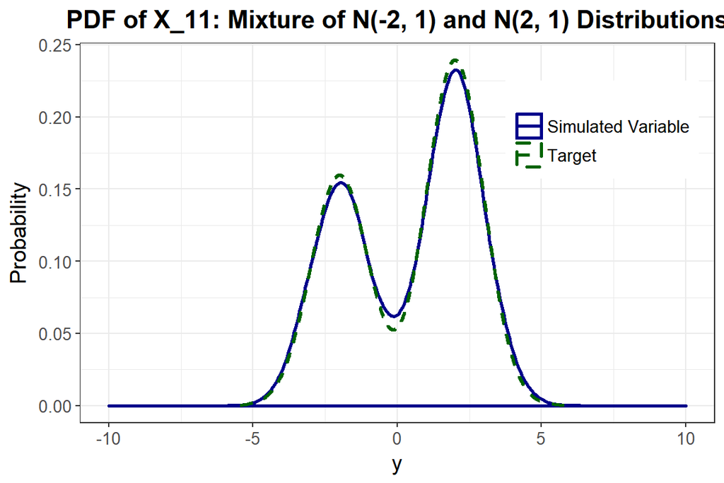

```r
Nplot <- plot_simpdf_theory(sim_y = Sys2$X_all[[1]][, 3], ylower = -10,
  yupper = 10,
  title = "PDF of X_11: Mixture of N(-2, 1) and N(2, 1) Distributions",
  fx = function(x) mix_pis[[1]][[1]][1] * dnorm(x, mix_mus[[1]][[1]][1],
    mix_sigmas[[1]][[1]][1]) + mix_pis[[1]][[1]][2] *
    dnorm(x, mix_mus[[1]][[1]][2], mix_sigmas[[1]][[1]][2]),
  lower = -Inf, upper = Inf)
Nplot
```

```r
knitr::kable(Sum2$target_mix_e, booktabs = TRUE,
  caption = "Target Distributions of Mixture Error Terms")
```

Table 22: Target Distributions of Mixture Error Terms

|  | Outcome | Mean | SD | Skew | Skurtosis | Fifth | Sixth |
| --- | --- | --- | --- | --- | --- | --- | --- |
| E1 | 1 | 1.163636 | 2.17086 | 2.013281 | 8.789539 | 36.48103 | 192.722 |
| E2 | 2 | 1.163636 | 2.17086 | 2.013281 | 8.789539 | 36.48103 | 192.722 |
| E3 | 3 | 1.163636 | 2.17086 | 2.013281 | 8.789539 | 36.48103 | 192.722 |

```r
knitr::kable(Sum2$mix_sum_e, booktabs = TRUE,
  caption = "Simulated Distributions of Mixture Error Terms")
```

Table 23: Simulated Distributions of Mixture Error Terms

|  | Outcome | N | Mean | SD | Median | Min | Max | Skew | Skurtosis | Fifth | Sixth |
| --- | --- | --- | --- | --- | --- | --- | --- | --- | --- | --- | --- |
| E1 | 1 | 10000 | 1.163636 | 2.170751 | 0.7848816 | -9.673026 | 23.10077 | 1.947736 | 8.372072 | 32.80773 | 167.3890 |
| E2 | 2 | 10000 | 1.163636 | 2.170751 | 0.7845759 | -9.483456 | 21.01385 | 2.079222 | 9.163271 | 36.52046 | 169.1260 |
| E3 | 3 | 10000 | 1.163636 | 2.170751 | 0.8101482 | -7.411084 | 20.11514 | 1.921233 | 8.176876 | 32.02805 | 146.7574 |

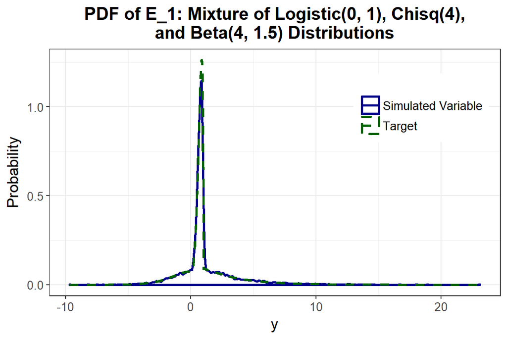

```r
Mplot <- plot_simpdf_theory(sim_y = Sys2$E_mix[, 1],
  title = paste("PDF of E_1: Mixture of Logistic(0, 1), Chisq(4),",
    "\nand Beta(4, 1.5) Distributions", sep = ""),
  fx = function(x) mix_pis[[1]][[2]][1] * dlogis(x, 0, 1) +
    mix_pis[[1]][[2]][2] * dchisq(x, 4) + mix_pis[[1]][[2]][3] *
    dbeta(x, 4, 1.5),
  lower = -Inf, upper = Inf)
Mplot
```

Maximum Correlation Errors for X Variables by Outcome:

```r
maxerr <- do.call(rbind, Sum2$maxerr)
rownames(maxerr) <- colnames(maxerr) <- paste("Y", 1:M, sep = "")
knitr::kable(as.data.frame(maxerr), digits = 5, booktabs = TRUE,
  caption = "Maximum Correlation Errors for X Variables")
```

Table 24: Maximum Correlation Errors for X Variables

|  | Y1 | Y2 | Y3 |
| --- | --- | --- | --- |
| Y1 | 0.00288 | 0.00405 | 0.00521 |
| Y2 | 0.00405 | 0.00170 | 0.00341 |
| Y3 | 0.00521 | 0.00341 | 0.00409 |

### Step 5: Compare simulated correlations to theoretical values

Since the system contains mixture variables, the mixture parameter inputs `mix_pis`, `mix_mus`, and `mix_sigmas` and the `error_type` must also be used.

```r
knitr::kable(calc_corr_y(Sys2$betas, corr.x, corr.e, vars, mix_pis,
  mix_mus, mix_sigmas, "mix"), booktabs = TRUE,
  caption = "Expected Y Correlations")
```

Table 25: Expected Y Correlations

|  | Y1 | Y2 | Y3 |
| --- | --- | --- | --- |
| Y1 | 1.0000000 | 0.2978052 | 0.3885223 |
| Y2 | 0.2978052 | 1.0000000 | 0.4785063 |
| Y3 | 0.3885223 | 0.4785063 | 1.0000000 |

```r
knitr::kable(Sum2$rho.y, booktabs = TRUE,
  caption = "Simulated Y Correlations")
```

Table 26: Simulated Y Correlations

|  | Y1 | Y2 | Y3 |
| --- | --- | --- | --- |
| Y1 | 1.0000000 | 0.2838656 | 0.3958264 |
| Y2 | 0.2838656 | 1.0000000 | 0.4717876 |
| Y3 | 0.3958264 | 0.4717876 | 1.0000000 |

```r
knitr::kable(calc_corr_ye(Sys2$betas, corr.x, corr.e, vars, mix_pis,
  mix_mus, mix_sigmas, "mix"), booktabs = TRUE,
  caption = "Expected Y, E Correlations")
```

Table 27: Expected Y, E Correlations

|  | E1 | E2 | E3 |
| --- | --- | --- | --- |
| Y1 | 0.8433984 | 0.1025981 | 0.1025981 |
| Y2 | 0.0944555 | 0.7764627 | 0.0944555 |
| Y3 | 0.0817148 | 0.0817148 | 0.6717288 |

```r
knitr::kable(Sum2$rho.yemix, booktabs = TRUE,
  caption = "Simulated Y, E Correlations")
```

Table 28: Simulated Y, E Correlations

|  | E1 | E2 | E3 |
| --- | --- | --- | --- |
| Y1 | 0.8433998 | 0.0788837 | 0.1088860 |
| Y2 | 0.0857085 | 0.7728459 | 0.0893955 |
| Y3 | 0.0881229 | 0.0692333 | 0.6696976 |

```r
knitr::kable(calc_corr_yx(Sys2$betas, corr.x, vars, mix_pis,
  mix_mus, mix_sigmas, "mix"), booktabs = TRUE,
  caption = "Expected Y, X Correlations")
```

Table 29: Expected Y, X Correlations

|  | X1_1 | X1_2 | X1_3 | X1_4 |
| --- | --- | --- | --- | --- |
| Y1 | 0.2999999 | 0.3000000 | 0.3000000 | 0.3000000 |
| Y2 | 0.4000002 | 0.1733719 | 0.1733719 | 0.1733719 |
| Y3 | 0.5000000 | 0.2804878 | 0.2804878 | 0.2804878 |

|  | X2_1 | X2_2 | X2_3 | X2_4 |
| --- | --- | --- | --- | --- |
| Y1 | 0.2999999 | 0.1924528 | 0.1924528 | 0.1924528 |
| Y2 | 0.4000002 | 0.4000000 | 0.4000000 | 0.4000000 |
| Y3 | 0.5000000 | 0.3902439 | 0.3902439 | 0.3902439 |

|  | X3_1 | X3_2 | X3_3 | X3_4 |
| --- | --- | --- | --- | --- |
| Y1 | 0.2999999 | 0.2886792 | 0.2886792 | 0.2886792 |
| Y2 | 0.4000002 | 0.3719248 | 0.3719248 | 0.3719248 |
| Y3 | 0.5000000 | 0.5000000 | 0.5000000 | 0.5000000 |

```r
knitr::kable(Sum2$rho.yx, booktabs = TRUE,
  caption = "Simulated Y, X Correlations")
```

Table 30: Simulated Y, X Correlations

|  | X1_1 | X1_2 | X1_3 | X1_4 |
| --- | --- | --- | --- | --- |
| Y1 | 0.3046310 | 0.2926216 | 0.3197465 | 0.2869766 |
| Y2 | 0.4002240 | 0.1577374 | 0.1697532 | 0.1652599 |
| Y3 | 0.4934152 | 0.2918114 | 0.2789633 | 0.2860321 |

|  | X2_1 | X2_2 | X2_3 | X2_4 |
| --- | --- | --- | --- | --- |
| Y1 | 0.3046310 | 0.1964025 | 0.1918824 | 0.1957318 |
| Y2 | 0.4002240 | 0.3971412 | 0.3928657 | 0.3970529 |
| Y3 | 0.4934152 | 0.4008303 | 0.3914031 | 0.3888395 |

|  | X3_1 | X3_2 | X3_3 | X3_4 |
| --- | --- | --- | --- | --- |
| Y1 | 0.3046310 | 0.2854515 | 0.2892292 | 0.2906667 |
| Y2 | 0.4002240 | 0.3729806 | 0.3633462 | 0.3700993 |
| Y3 | 0.4934152 | 0.5087496 | 0.5014829 | 0.5009007 |

## Example 3: System of 3 equations, $Y_1$ and $Y_3$ as in Example 2, $Y_2$ has only error term

In this example:

1. $X_{11} = X_{31}$ has a Logistic(0, 1) distribution and is the same variable for $Y_1$ and $Y_3$
2. $X_{12}, X_{32}$ have Beta(4, 1.5) distributions
3. $X_{13}, X_{33}$ have normal mixture distributions
4. $E_1, E_2, E_3$ have Logistic, Chisq, Beta mixture distributions

$$\begin{equation}
\begin{split}
Y_1 &= \beta_{10} + \beta_{11} * X_{11} + \beta_{12} * X_{12} + \beta_{13} * X_{13} + E_1 \\
Y_2 &= \beta_{20} + E_2 \\
Y_3 &= \beta_{30} + \beta_{31} * X_{11} + \beta_{32} * X_{32} + \beta_{33} * X_{33} + E_3
\end{split}
\tag{3}
\end{equation}$$

### Step 1: Set up parameter inputs

```r
seed <- 276
n <- 10000
M <- 3

method <- "Polynomial"
L <- calc_theory("Logistic", c(0, 1))
C <- calc_theory("Chisq", 4)
B <- calc_theory("Beta", c(4, 1.5))

skews <- list(c(L[3], B[3]), NULL, c(L[3], B[3]))
skurts <- list(c(L[4], B[4]), NULL, c(L[4], B[4]))
fifths <- list(c(L[5], B[5]), NULL, c(L[5], B[5]))
sixths <- list(c(L[6], B[6]), NULL, c(L[6], B[6]))
Six <- list(list(1.75, 0.03), NULL, list(1.75, 0.03))

mix_pis <- list(list(c(0.4, 0.6), c(0.3, 0.2, 0.5)), list(c(0.3, 0.2, 0.5)),
  list(c(0.4, 0.6), c(0.3, 0.2, 0.5)))
mix_mus <- list(list(c(-2, 2), c(L[1], C[1], B[1])), list(c(L[1], C[1], B[1])),
  list(c(-2, 2), c(L[1], C[1], B[1])))
mix_sigmas <- list(list(c(1, 1), c(L[2], C[2], B[2])),
  list(c(L[2], C[2], B[2])), list(c(1, 1), c(L[2], C[2], B[2])))
mix_skews <- list(list(c(0, 0), c(L[3], C[3], B[3])),
  list(c(L[3], C[3], B[3])), list(c(0, 0), c(L[3], C[3], B[3])))
mix_skurts <- list(list(c(0, 0), c(L[4], C[4], B[4])),
  list(c(L[4], C[4], B[4])),list(c(0, 0), c(L[4], C[4], B[4])))
mix_fifths <- list(list(c(0, 0), c(L[5], C[5], B[5])),
  list(c(L[5], C[5], B[5])), list(c(0, 0), c(L[5], C[5], B[5])))
mix_sixths <- list(list(c(0, 0), c(L[6], C[6], B[6])),
  list(c(L[6], C[6], B[6])), list(c(0, 0), c(L[6], C[6], B[6])))
mix_Six <- list(list(NULL, NULL, 1.75, NULL, 0.03), list(1.75, NULL, 0.03),
  list(NULL, NULL, 1.75, NULL, 0.03))
means <- list(c(L[1], B[1], Nstcum[1], Mstcum[1]), Mstcum[1],
  c(L[1], B[1], Nstcum[1], Mstcum[1]))
vars <- list(c(L[2]^2, B[2]^2, Nstcum[2]^2, Mstcum[2]^2), Mstcum[2]^2,
  c(L[2]^2, B[2]^2, Nstcum[2]^2, Mstcum[2]^2))

# since Y_2 has no X variables, same.var must be changed to a matrix
same.var <- matrix(c(1, 1, 3, 1), 1, 4)

corr.x <- list(list(matrix(0.1, 4, 4), NULL, matrix(0.3, 4, 4)), NULL)
diag(corr.x[[1]][[1]]) <- 1

# set correlations between components of the same mixture variable to 0
corr.x[[1]][[1]][3:4, 3:4] <- diag(2)

# since X1 is the same across outcomes, set correlation the same
corr.x[[1]][[3]][, 1] <- corr.x[[1]][[1]][, 1]

corr.x <- append(corr.x, list(list(t(corr.x[[1]][[3]]), NULL, matrix(0.5, 4, 4))))
diag(corr.x[[3]][[3]]) <- 1

# set correlations between components of the same mixture variable to 0
corr.x[[3]][[3]][3:4, 3:4] <- diag(2)

# since X1 is the same across outcomes, set correlation the same
corr.x[[3]][[3]][, 1] <- t(corr.x[[1]][[3]][1, ])
corr.x[[3]][[3]][1, ] <- t(corr.x[[3]][[3]][, 1])

corr.yx <- list(matrix(0.3, 1, 4), NULL, matrix(0.5, 1, 4))

corr.e <- matrix(0.4, 9, 9)
corr.e[1:3, 1:3] <- corr.e[4:6, 4:6] <- corr.e[7:9, 7:9] <- diag(3)
error_type = "mix"
```

### Step 2: Check parameter inputs

```r
checkpar(M, method, error_type, means, vars, skews, skurts, fifths, sixths,
  Six, mix_pis, mix_mus, mix_sigmas, mix_skews, mix_skurts, mix_fifths,
  mix_sixths, mix_Six, same.var = same.var, betas.0 = betas.0, corr.x = corr.x,
  corr.yx = corr.yx, corr.e = corr.e, quiet = TRUE)
```

```
## [1] TRUE
```

### Step 3: Generate system

```r
Sys3 <- nonnormsys(n, M, method, error_type, means, vars, skews, skurts,
  fifths, sixths, Six, mix_pis, mix_mus, mix_sigmas, mix_skews, mix_skurts,
  mix_fifths, mix_sixths, mix_Six, same.var, betas.0, corr.x, corr.yx, corr.e,
  seed, use.nearPD = FALSE, quiet = TRUE)
```

```
## Total Simulation time: 0.011 minutes
```

```r
knitr::kable(Sys3$betas, booktabs = TRUE, caption = "Beta coefficients")
```

Table 31: Beta coefficients

|  | B1 | B2 | B3 | B4 |
| --- | --- | --- | --- | --- |
| Y1 | 0.3213033 | 3.336167 | 0.6556271 | 0.6556271 |
| Y2 | 0.0000000 | 0.000000 | 0.0000000 | 0.0000000 |
| Y3 | 0.4345749 | 0.000000 | 1.3794056 | 1.3794056 |

```r
knitr::kable(Sys3$constants[[1]], booktabs = TRUE, caption = "PMT constants")
```

Table 32: PMT constants

| c0 | c1 | c2 | c3 | c4 | c5 |
| --- | --- | --- | --- | --- | --- |
| 0.0000000 | 0.8879258 | 0.0000000 | 0.0360523 | 0.0000000 | 0.0000006 |
| 0.1629657 | 1.0899841 | -0.1873287 | -0.0449503 | 0.0081210 | 0.0014454 |
| 0.0000000 | 1.0000000 | 0.0000000 | 0.0000000 | 0.0000000 | 0.0000000 |
| 0.0000000 | 1.0000000 | 0.0000000 | 0.0000000 | 0.0000000 | 0.0000000 |
| 0.0000000 | 0.8879258 | 0.0000000 | 0.0360523 | 0.0000000 | 0.0000006 |
| -0.2275081 | 0.9007156 | 0.2316099 | 0.0154662 | -0.0013673 | 0.0000552 |
| 0.1629657 | 1.0899841 | -0.1873287 | -0.0449503 | 0.0081210 | 0.0014454 |

```r
Sys3$valid.pdf
```

```
## [[1]]
## [1] "TRUE" "TRUE" "TRUE" "TRUE" "TRUE" "TRUE" "TRUE"
##
## [[2]]
## [1] "TRUE" "TRUE" "TRUE"
##
## [[3]]
## [1] "TRUE" "TRUE" "TRUE" "TRUE" "TRUE" "TRUE" "TRUE"
```

### Step 4: Describe results

```r
Sum3 <- summary_sys(Sys3$Y, Sys3$E, Sys3$E_mix, Sys3$X, Sys3$X_all, M, method,
  means, vars, skews, skurts, fifths, sixths, mix_pis, mix_mus, mix_sigmas,
  mix_skews, mix_skurts, mix_fifths, mix_sixths, corr.x = corr.x,
  corr.e = corr.e)
```

```r
knitr::kable(Sum3$cont_sum_y, booktabs = TRUE,
  caption = "Simulated Distributions of Outcomes")
```

Table 33: Simulated Distributions of Outcomes

|  | Outcome | N | Mean | SD | Median | Min | Max | Skew | Skurtosis | Fifth | Sixth |
| --- | --- | --- | --- | --- | --- | --- | --- | --- | --- | --- | --- |
| Y1 | 1 | 10000 | 3.589515 | 2.561356 | 3.3343275 | -6.173603 | 27.29735 | 1.2077687 | 4.570660 | 17.098230 | 83.88966 |
| Y2 | 2 | 10000 | 1.163636 | 2.170751 | 0.8114017 | -10.198298 | 17.51876 | 1.9371481 | 8.312887 | 29.395190 | 114.56563 |
| Y3 | 3 | 10000 | 1.163810 | 3.223408 | 0.9884224 | -11.205198 | 21.47867 | 0.5828432 | 1.737082 | 4.733577 | 14.03912 |

```r
knitr::kable(Sum3$target_sum_x, booktabs = TRUE,
  caption = "Target Distributions of Independent Variables")
```

Table 34: Target Distributions of Independent Variables

|  | Outcome | X | Mean | SD | Skew | Skurtosis | Fifth | Sixth |
| --- | --- | --- | --- | --- | --- | --- | --- | --- |
| cont1_1 | 1 | 1 | 0.0000000 | 1.8137994 | 0.0000000 | 1.2000000 | 0.000000 | 6.857143 |
| cont1_2 | 1 | 2 | 0.7272727 | 0.1746854 | -0.6938789 | -0.0686029 | 1.828251 | -3.379110 |
| cont1_3 | 1 | 3 | -2.0000000 | 1.0000000 | 0.0000000 | 0.0000000 | 0.000000 | 0.000000 |
| cont1_4 | 1 | 4 | 2.0000000 | 1.0000000 | 0.0000000 | 0.0000000 | 0.000000 | 0.000000 |
| cont3_1 | 3 | 1 | 0.0000000 | 1.8137994 | 0.0000000 | 1.2000000 | 0.000000 | 6.857143 |
| cont3_2 | 3 | 2 | 0.7272727 | 0.1746854 | -0.6938789 | -0.0686029 | 1.828251 | -3.379110 |
| cont3_3 | 3 | 3 | -2.0000000 | 1.0000000 | 0.0000000 | 0.0000000 | 0.000000 | 0.000000 |
| cont3_4 | 3 | 4 | 2.0000000 | 1.0000000 | 0.0000000 | 0.0000000 | 0.000000 | 0.000000 |

```r
knitr::kable(Sum3$cont_sum_x, booktabs = TRUE,
  caption = "Simulated Distributions of Independent Variables")
```

Table 35: Simulated Distributions of Independent Variables

|  | Outcome | X | N | Mean | SD | Median | Min | Max | Skew | Skurtosis | Fifth | Sixth |
| --- | --- | --- | --- | --- | --- | --- | --- | --- | --- | --- | --- | --- |
| cont1_1 | 1 | 1 | 10000 | 0.0004003 | 1.8086659 | -0.0034553 | -9.3357455 | 8.093322 | 0.0093534 | 0.9026131 | -0.0030437 | 1.4023271 |
| cont1_2 | 1 | 2 | 10000 | 0.7271071 | 0.1743004 | 0.7532079 | 0.0867398 | 1.083444 | -0.6761726 | -0.1000023 | 1.7778230 | -3.0225169 |
| cont1_3 | 1 | 3 | 10000 | -2.0000000 | 0.9999500 | -1.9820874 | -6.1670779 | 1.579041 | -0.0138124 | 0.0450324 | -0.0467214 | -0.1399622 |
| cont1_4 | 1 | 4 | 10000 | 2.0000000 | 0.9999500 | 2.0192696 | -1.8671048 | 5.818930 | -0.0259989 | 0.0660603 | 0.0980029 | -0.4313656 |
| cont3_1 | 3 | 1 | 10000 | 0.0004003 | 1.8086659 | -0.0034553 | -9.3357455 | 8.093322 | 0.0093534 | 0.9026131 | -0.0030437 | 1.4023271 |
| cont3_2 | 3 | 2 | 10000 | 0.7273631 | 0.1752534 | 0.7601429 | 0.0711494 | 1.034962 | -0.7030286 | -0.0889725 | 1.9270159 | -3.3525250 |
| cont3_3 | 3 | 3 | 10000 | -2.0000000 | 0.9999500 | -1.9947523 | -5.8932382 | 1.483459 | -0.0447962 | -0.0478362 | -0.0040827 | -0.1491799 |
| cont3_4 | 3 | 4 | 10000 | 2.0000000 | 0.9999500 | 2.0119310 | -1.6266392 | 6.083537 | -0.0019161 | -0.0060812 | 0.2566953 | 0.2512733 |

```r
knitr::kable(Sum3$target_mix_x, booktabs = TRUE,
  caption = "Target Distributions of Mixture Independent Variables")
```

Table 36: Target Distributions of Mixture Independent Variables

|  | Outcome | X | Mean | SD | Skew | Skurtosis | Fifth | Sixth |
| --- | --- | --- | --- | --- | --- | --- | --- | --- |
| mix1_1 | 1 | 1 | 0.4 | 2.2 | -0.2885049 | -1.154019 | 1.793022 | 6.173267 |
| mix3_1 | 3 | 1 | 0.4 | 2.2 | -0.2885049 | -1.154019 | 1.793022 | 6.173267 |

```r
knitr::kable(Sum3$mix_sum_x, booktabs = TRUE,
  caption = "Simulated Distributions of Mixture Independent Variables")
```

Table 37: Simulated Distributions of Mixture Independent Variables

|  | Outcome | X | N | Mean | SD | Median | Min | Max | Skew | Skurtosis | Fifth | Sixth |
| --- | --- | --- | --- | --- | --- | --- | --- | --- | --- | --- | --- | --- |
| mix1_1 | 1 | 1 | 10000 | 0.4 | 2.19989 | 1.03944 | -6.140646 | 5.801265 | -0.2961194 | -1.141168 | 1.808030 | 6.086474 |
| mix3_1 | 3 | 1 | 10000 | 0.4 | 2.19989 | 1.05123 | -5.487086 | 6.058566 | -0.2866761 | -1.152828 | 1.791524 | 6.199999 |

```r
knitr::kable(Sum3$target_mix_e, booktabs = TRUE,
  caption = "Target Distributions of Mixture Error Terms")
```

Table 38: Target Distributions of Mixture Error Terms

|  | Outcome | Mean | SD | Skew | Skurtosis | Fifth | Sixth |
| --- | --- | --- | --- | --- | --- | --- | --- |
| E1 | 1 | 1.163636 | 2.17086 | 2.013281 | 8.789539 | 36.48103 | 192.722 |
| E2 | 2 | 1.163636 | 2.17086 | 2.013281 | 8.789539 | 36.48103 | 192.722 |
| E3 | 3 | 1.163636 | 2.17086 | 2.013281 | 8.789539 | 36.48103 | 192.722 |

```r
knitr::kable(Sum3$mix_sum_e, booktabs = TRUE,
  caption = "Simulated Distributions of Mixture Error Terms")
```

Table 39: Simulated Distributions of Mixture Error Terms

|  | Outcome | N | Mean | SD | Median | Min | Max | Skew | Skurtosis | Fifth | Sixth |
| --- | --- | --- | --- | --- | --- | --- | --- | --- | --- | --- | --- |
| E1 | 1 | 10000 | 1.163636 | 2.170751 | 0.7763939 | -7.337748 | 25.01447 | 2.027964 | 8.810501 | 39.02100 | 230.4321 |
| E2 | 2 | 10000 | 1.163636 | 2.170751 | 0.8114017 | -10.198298 | 17.51876 | 1.937148 | 8.312887 | 29.39519 | 114.5656 |
| E3 | 3 | 10000 | 1.163636 | 2.170751 | 0.8072152 | -9.407838 | 18.95352 | 1.920803 | 8.312115 | 30.29603 | 124.0343 |

Maximum Correlation Errors for X Variables by Outcome:

```r
maxerr <- rbind(Sum3$maxerr[[1]][-2], Sum3$maxerr[[3]][-2])
rownames(maxerr) <- colnames(maxerr) <- c("Y1", "Y3")
knitr::kable(as.data.frame(maxerr), digits = 5, booktabs = TRUE,
  caption = "Maximum Correlation Errors for X Variables")
```

Table 40: Maximum Correlation Errors for X Variables

|  | Y1 | Y3 |
| --- | --- | --- |
| Y1 | 0.00177 | 0.00147 |
| Y3 | 0.00147 | 0.00257 |

### Step 5: Compare simulated correlations to theoretical values

```r
knitr::kable(calc_corr_y(Sys3$betas, corr.x, corr.e, vars, mix_pis,
  mix_mus, mix_sigmas, "mix"), booktabs = TRUE,
  caption = "Expected Y Correlations")
```

Table 41: Expected Y Correlations

|  | Y1 | Y2 | Y3 |
| --- | --- | --- | --- |
| Y1 | 1.0000000 | 0.1025981 | 0.3885224 |
| Y2 | 0.1025981 | 1.0000000 | 0.0817148 |
| Y3 | 0.3885224 | 0.0817148 | 1.0000000 |

```r
knitr::kable(Sum3$rho.y, booktabs = TRUE,
  caption = "Simulated Y Correlations")
```

Table 42: Simulated Y Correlations

|  | Y1 | Y2 | Y3 |
| --- | --- | --- | --- |
| Y1 | 1.0000000 | 0.0738147 | 0.3825892 |
| Y2 | 0.0738147 | 1.0000000 | 0.0611834 |
| Y3 | 0.3825892 | 0.0611834 | 1.0000000 |

```r
knitr::kable(calc_corr_ye(Sys3$betas, corr.x, corr.e, vars, mix_pis,
  mix_mus, mix_sigmas, "mix"), booktabs = TRUE,
  caption = "Expected Y, E Correlations")
```

Table 43: Expected Y, E Correlations

|  | E1 | E2 | E3 |
| --- | --- | --- | --- |
| Y1 | 0.8433983 | 0.1025981 | 0.1025981 |
| Y2 | 0.1216485 | 1.0000000 | 0.1216485 |
| Y3 | 0.0817148 | 0.0817148 | 0.6717288 |

```r
knitr::kable(Sum3$rho.yemix, booktabs = TRUE,
  caption = "Simulated Y, E Correlations")
```

Table 44: Simulated Y, E Correlations

|  | E1 | E2 | E3 |
| --- | --- | --- | --- |
| Y1 | 0.8421445 | 0.0738147 | 0.0966026 |
| Y2 | 0.0912775 | 1.0000000 | 0.0993515 |
| Y3 | 0.0742094 | 0.0611834 | 0.6704631 |

```r
knitr::kable(calc_corr_yx(Sys3$betas, corr.x, vars, mix_pis,
  mix_mus, mix_sigmas, "mix"), booktabs = TRUE,
  caption = "Expected Y, X Correlations")
```

Table 45: Expected Y, X Correlations

|  | X1_1 | X1_2 | X1_3 | X1_4 |
| --- | --- | --- | --- | --- |
| Y1 | 0.3 | 0.3000000 | 0.3000000 | 0.3000000 |
| Y2 | 0.0 | 0.0000000 | 0.0000000 | 0.0000000 |
| Y3 | 0.5 | 0.2804878 | 0.2804878 | 0.2804878 |

|  | X3_1 | X3_2 | X3_3 | X3_4 |
| --- | --- | --- | --- | --- |
| Y1 | 0.3 | 0.2886793 | 0.2886793 | 0.2886793 |
| Y2 | 0.0 | 0.0000000 | 0.0000000 | 0.0000000 |
| Y3 | 0.5 | 0.5000000 | 0.5000000 | 0.5000000 |

```r
knitr::kable(Sum3$rho.yx, booktabs = TRUE,
  caption = "Simulated Y, X Correlations")
```

Table 46: Simulated Y, X Correlations

|  | X1_1 | X1_2 | X1_3 | X1_4 |
| --- | --- | --- | --- | --- |
| Y1 | 0.2889926 | 0.2964159 | 0.2877044 | 0.3116951 |
| Y2 | 0.0014158 | -0.0077903 | -0.0056745 | -0.0025133 |
| Y3 | 0.5030255 | 0.2748050 | 0.2790685 | 0.2803257 |

|  | X3_1 | X3_2 | X3_3 | X3_4 |
| --- | --- | --- | --- | --- |
| Y1 | 0.2889926 | 0.2873456 | 0.2900545 | 0.2873188 |
| Y2 | 0.0014158 | -0.0002223 | -0.0097569 | -0.0044247 |
| Y3 | 0.5030255 | 0.4990494 | 0.4886098 | 0.5065214 |

# References

Bates, Douglas, and Martin Maechler. 2017. *Matrix: Sparse and Dense Matrix Classes and Methods*. https://CRAN.R-project.org/package=Matrix.

Davenport, JW, JC Bezder, and RJ Hathaway. 1988. “Parameter Estimation for Finite Mixture Distributions.” *Computers & Mathematics with Applications* 15 (10): 819–28.

Everitt, B S. 1996. “An Introduction to Finite Mixture Distributions.” *Statistical Methods in Medical Research* 5 (2): 107–27. https://doi.org/10.1177/096228029600500202.

Fialkowski, A C. 2017. *SimMultiCorrData: Simulation of Correlated Data with Multiple Variable Types*. https://CRAN.R-project.org/package=SimMultiCorrData.

———. 2018. *SimCorrMix: Simulation of Correlated Data with Multiple Variable Types Including Continuous and Count Mixture Distributions*. https://CRAN.R-project.org/package=SimCorrMix.

Fleishman, A I. 1978. “A Method for Simulating Non-Normal Distributions.” *Psychometrika* 43: 521–32. https://doi.org/10.1007/BF02293811.

Headrick, T C. 2002. “Fast Fifth-Order Polynomial Transforms for Generating Univariate and Multivariate Non-Normal Distributions.” *Computational Statistics and Data Analysis* 40 (4): 685–711. https://doi.org/10.1016/S0167-9473(02)00072-5.

Headrick, T C, and T M Beasley. 2004. “A Method for Simulating Correlated Non-Normal Systems of Statistical Equations.” *Communications in Statistics - Simulation and Computation* 33 (1): 19–33. http://dx.doi.org/10.1081/SAC-120028431.

Higham, N. 2002. “Computing the Nearest Correlation Matrix - a Problem from Finance.” *IMA Journal of Numerical Analysis* 22 (3): 329–43. https://doi.org/10.1093/imanum/22.3.329.

Maree, S. 2012. “Correcting Non Positive Definite Correlation Matrices.” BSc Thesis Applied Mathematics, Delft University of Technology. http://resolver.tudelft.nl/uuid:2175c274-ab03-4fd5-85a9-228fe421cdbf.

Pearson, RK. 2011. “Exploring Data in Engineering, the Sciences, and Medicine.” In. New York: Oxford University Press.

Shork, N J, D B Allison, and B Thiel. 1996. “Mixture Distributions in Human Genetics Research.” *Statistical Methods in Medical Research* 5: 155–78. https://doi.org/10.1177/096228029600500204.

Yin, JF, and Y Zhang. 2013. “Alternative Gradient Algorithms for Computing the Nearest Correlation Matrix.” *Applied Mathematics and Computation* 219 (14): 7591–9. https://doi.org/10.1016/j.amc.2013.01.045.

Zhang, Y, and JF Yin. Year not provided. “Modified Alternative Gradients Algorithm for Computing the Nearest Correlation Matrix.” Internal paper. Shanghai: Tongji University.